# Explorary Data Analize(EDA)

Egor Suslin (richardrex: https://github.com/richardrex)

25/05/2020

## 1.1 Inroduction

I would like to present you R MarkDown report of European rivers. As default datasets, I had river`s basic info(name of stations, name of rivers, country, continent, longtitude, altitude, latitude and number of obsarvation)

```
##         ID    Station         River Country Continent   Lat      Lon Alt
## 1: 6123100   MONTJEAN         LOIRE      FR        EU 47.38 -0.83000   9
## 2: 6123300      BLOIS         LOIRE      FR        EU 47.58  1.33000  66
## 3: 6140400      DECIN    ELBE RIVER      CZ        EU 50.79 14.23000 120
## 4: 6140700      NEKOR DIVOKA ORLICE      CZ        EU 50.07 16.55000  NA
## 5: 6142100 MORAVICANY        MORAVA      CZ        EU 49.75 16.96667 244
## 6: 6142120  STRAZNICE        MORAVA      CZ        EU 48.93 17.31667  NA
##    N.Years
## 1:     117
## 2:     117
## 3:     162
## 4:     107
## 5:     102
## 6:      82
```

So, using this information, can create a map with location of all stations presented in runoff_eu_info.rds

[interactive chart not shown]

As you can see, bigger part of all stations are located in Central Europe. Another big group of stations is located in Northern Europe (Northland) and only small part is located in Eastern Europe (mostly Russia).

# 2 Stations

```r
head(station_per_country)
```

```
##    Country  N
## 1:      FR  2
## 2:      CZ  5
## 3:      SK  2
## 4:      SE 27
## 5:      DE 78
## 6:      IS  1
```

Second one shows amount of rivers in all European countries. We can see, that amount of stations bigger, than rivers. The reason of it is to collect as much data as possible, and present more clearly results.

```r
head(rivers_per_country)
```

```
##    Country  N
## 1:      FR  1
## 2:      CZ  4
## 3:      SK  2
## 4:      SE 26
## 5:      DE 51
## 6:      IS  1
```

And finally amount stations located in different rivers.

```r
head(stations_per_river)
```

```
##            River  N
## 1:         LOIRE  2
## 2:    ELBE RIVER  5
## 3: DIVOKA ORLICE  1
## 4:        MORAVA  2
## 5:  DANUBE RIVER 13
## 6:           VAH  1
```

As we can see from next table, bigger amount of all stations have more than 100 years of obsarvation. On the other hand, some of station have less than 90 years of obsarvation. That means, that I should be very careful with data manipulation.

```r
head(years)
```

```
##       Station N.Years
## 1:   MONTJEAN     117
## 2:      BLOIS     117
## 3:      DECIN     162
## 4:      NEKOR     107
## 5: MORAVICANY     102
## 6:  STRAZNICE      82
```

# 3 Annual and daily runoff

Here presented 3 data tables with different descriptive statistics. runoff_char.rds containes mean, coefficient of variance, minimum and maximum runoff with annual data, skew and min/max ratio Need this for futher data manipulations, that are provided in folder /code in annual_daily_runoff.R

```r
head(characteristic_1)
```

```
##         ID max_range min_range
## 1: 6123100    5401.0    1748.0
## 2: 6140400    4464.0     207.0
## 3: 6140700     106.0      10.0
## 4: 6142100     561.8       5.0
## 5: 6142120     833.5     139.7
## 6: 6142200    9675.0    1900.0
```

```r
head(characteristic_2)
```

```
##         ID max_range min_range Alt max_range_class min_range_class
## 1: 6123100    5401.0    1748.0   9            high            high
## 2: 6140400    4464.0     207.0 120          medium             low
## 3: 6140700     106.0      10.0  NA             low             low
## 4: 6142100     561.8       5.0 244             low             low
## 5: 6142120     833.5     139.7  NA             low             low
## 6: 6142200    9675.0    1900.0 128            high            high
##    alt_range_class
## 1:             low
## 2:             low
## 3:            <NA>
## 4:          medium
## 5:            <NA>
## 6:             low
```

```r
head(runoff_char)
```

```
##         id year      mean  max min        sd median       COV      skew
## 1: 6123100 1963  879.6548 2570 222  572.6777  695.0 0.6510255 0.9673232
## 2: 6123100 1964  568.8279 2400 125  564.6060  322.0 0.9925779 1.3115051
## 3: 6123100 1965  982.5589 3800 178  782.1658  720.0 0.7960498 1.0070457
## 4: 6123100 1966 1313.7288 4320 173 1078.9884 1070.0 0.8213175 0.6776591
## 5: 6123100 1967  764.7068 2740 180  605.8043  590.0 0.7922046 0.8651648
## 6: 6123100 1968 1021.6120 5010 263  796.2477  797.5 0.7794032 0.8443806
##    mean_max_ratio mean_min_ratio range
## 1:      0.3422781       3.962409  2348
## 2:      0.2370116       4.550623  2275
## 3:      0.2585681       5.519994  3622
## 4:      0.3041039       7.593808  4147
## 5:      0.2790901       4.248371  2560
## 6:      0.2039146       3.884456  4747
```

In same file created a loop to see ratios of mean/high and mean/low runoff. Then put all data to new table

```r
head(ratio_difference_2)
```

```
##         ID max_range_class min_range_class alt_range_class meanmax_difference
## 1: 6140400          medium             low             low        0.026489779
## 2: 6140700             low             low            <NA>        0.022352546
## 3: 6142100             low             low          medium       -0.010694465
## 4: 6142120             low             low            <NA>        0.004425525
## 5: 6142200            high            high             low       -0.008956713
## 6: 6142620             low             low             low       -0.006346998
##    meanmin_difference
## 1:        0.026489779
## 2:        0.022352546
## 3:       -0.010694465
## 4:        0.004425525
## 5:       -0.008956713
## 6:       -0.006346998
```

After manipulations(winter and summer runoff before and after 1980), we can plot change of mean runnoff at stations before and after 1980 in summer and in winter

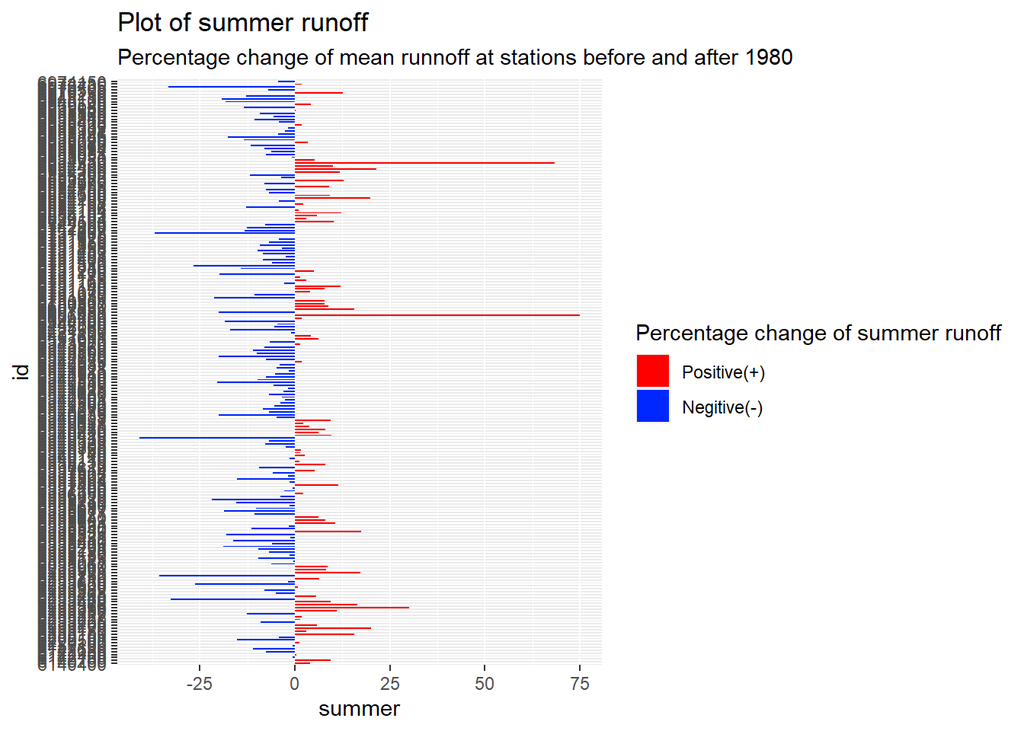

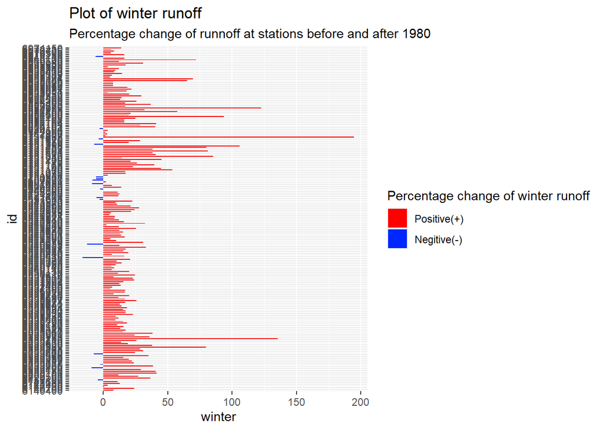

# 4 5 Rivers

Now we choose 5 different rivers. Dicided to choose stations at approximately equal and lower altitude(due to climate:a lot of precipitation) and with common year of observation(will be easy to compare) Rivers: ELBE, DANUBE RIVER, DEE (SCOTLAND), KOKEMAENJOKI, WESER. Human influence info: Elbe: https://www.clisap.de/clisap/about-us/news/human-impact-on-elbe-river-remains-severe/. Dunabe: https://www.icpdr.org/main/issues/human-impacts. http://archive.iwlearn.net/undp-drp.org/drp/danube_human_activities.html.

Dee (SCOTLAND): http://www.riverdee.org.uk/education/introdee.

Don`t find articles about Kokemaenjoki and Weser.

First need to create new table with 5 rivers info and table with runoff of this 5 rivers.

```
##         ID                             Station          River Country Continent
## 1: 6340150                         WITTENBERGE     ELBE RIVER      DE        EU
## 2: 6742200 ORSOVA (1971:DROBATA-TURNU SEVERIN)   DANUBE RIVER      RO        EU
## 3: 6604800                             WOODEND DEE (SCOTLAND)      GB        EU
## 4: 6854106              SAEAEKSJAERVI - OUTLET   KOKEMAENJOKI      FI        EU
## 5: 6337200                           INTSCHEDE          WESER      DE        EU
##      Lat      Lon Alt N.Years
## 1: 52.99 11.75976  17     115
## 2: 44.70 22.42000  44     151
## 3: 57.05 -2.60000  71      85
## 4: 61.38 22.46783  50      93
## 5: 52.96  9.12500   4     155
```

```
##         id       date value month year
## 1: 6337200 1857-01-03   407    01 1857
## 2: 6337200 1857-01-08   617    01 1857
## 3: 6337200 1857-01-13   384    01 1857
## 4: 6337200 1857-01-18   256    01 1857
## 5: 6337200 1857-01-23   347    01 1857
## 6: 6337200 1857-01-28   272    01 1857
```

Now going to create box plot with the runoff seasonality at monthly scale. We can do this with mean() function of value in table runoff_5_rivers.rds.

```r
head(seasonal_discharge)
```

```
##         id month year       V1
## 1: 6337200    01 1857 380.5000
## 2: 6337200    02 1857 258.1667
## 3: 6337200    03 1857 281.6667
## 4: 6337200    04 1857 297.5000
## 5: 6337200    05 1857 193.5000
## 6: 6337200    06 1857 150.3333
```

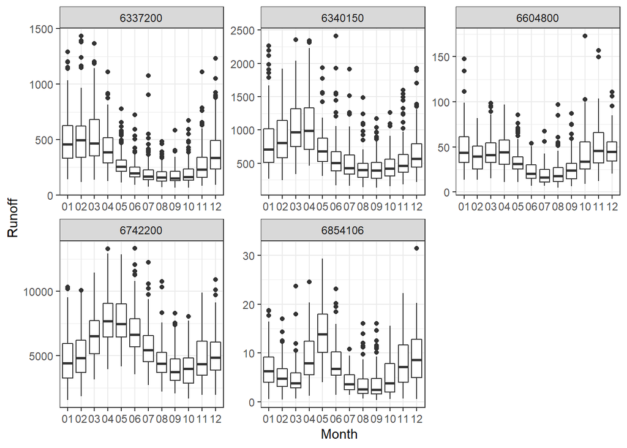

```r
ggplot(seasonal_discharge, aes(x = factor(month), y = V1, group = month)) +
  geom_boxplot() +
  facet_wrap(~id, scales = 'free') +
  xlab(label = "Month") +
  ylab(label = "Runoff") +
  theme_bw()
```

Then we need to present the slopes in winter/summer runoff per our 5 rivers. Need separate seasons with function factor() and then create a plot with this data

```r
head(winter_runnof)
```

```
##    year      id    V1
## 1:   18 6337200  5522
## 2:   19 6337200  3869
## 3:   20 6337200  6361
## 4:   21 6337200  7835
## 5:   22 6337200 13886
## 6:   23 6337200 12243
```

```r
head(summer_runnof)
```

```
##    year      id     V1
## 1:   18 6337200 1919.0
## 2:   19 6337200 2728.7
## 3:   20 6337200 1923.1
## 4:   21 6337200 3847.0
## 5:   22 6337200 4753.0
## 6:   23 6337200 5444.0
```

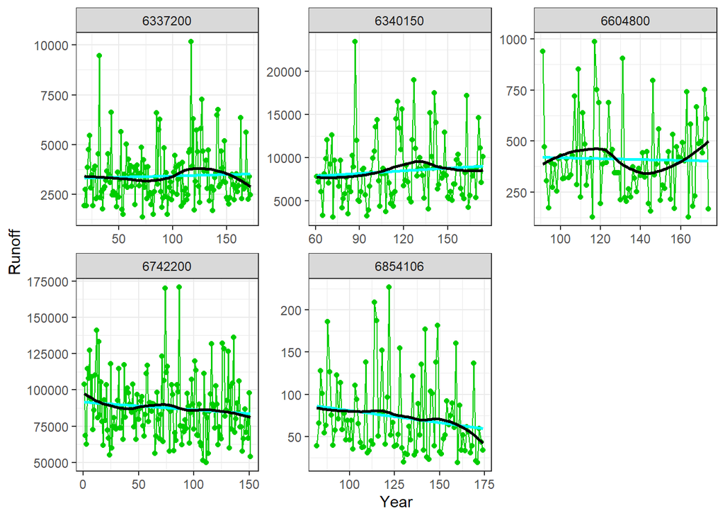

```r
ggplot(summer_runnof, aes(x = year, y = V1)) +
  geom_line(col = colset_4[3], aes(group = 1))+
  geom_point(col = colset_4[3])+
  facet_wrap(~id, scales = 'free') +
  geom_smooth(method = 'lm', formula = y~x, se = 0, col = colset_4[1]) +
  geom_smooth(method = 'loess', formula = y~x, se = 0, col = colset_4[4]) +
  scale_color_manual(values = colset_4[c(1, 2, 3, 4)]) +
  xlab(label = "Year") +
  ylab(label = "Runoff") +
  theme_bw()
```

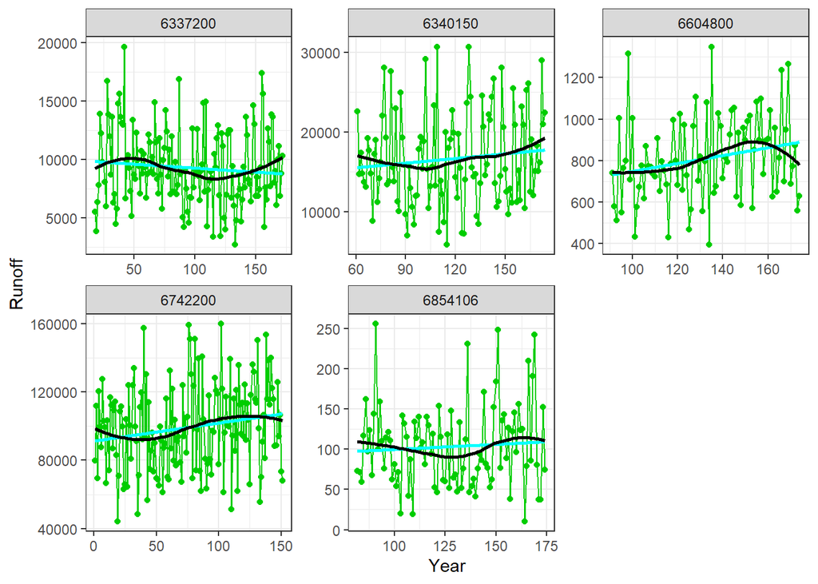

```r
ggplot(winter_runnof, aes(x = year, y = V1)) +
  geom_line(col = colset_4[3], aes(group = 1))+
  geom_point(col = colset_4[3])+
  facet_wrap(~id, scales = 'free') +
  geom_smooth(method = 'lm', formula = y~x, se = 0, col = colset_4[1]) +
  geom_smooth(method = 'loess', formula = y~x, se = 0, col = colset_4[4]) +
  scale_color_manual(values = colset_4[c(1, 2, 3, 4)]) +
  xlab(label = "Year") +
  ylab(label = "Runoff") +
  theme_bw()
```

```r
head(all_stations_winter_runoff)
```

```
##    year      id     V1
## 1: 1963 6123100 122495
## 2: 1964 6123100  80236
## 3: 1965 6123100  84166
## 4: 1966 6123100 234180
## 5: 1967 6123100 144675
## 6: 1968 6123100 178820
```

```r
head(all_stations_summer_runoff)
```

```
##    year      id    V1
## 1: 1963 6123100 40873
## 2: 1964 6123100 14470
## 3: 1965 6123100 41522
## 4: 1966 6123100 27039
## 5: 1967 6123100 22455
## 6: 1968 6123100 42707
```

```r
summer_runoff_15 <- all_stations_summer_runoff[1:15]
winter_runoff_15 <- all_stations_winter_runoff[1:15]
```

[figure not shown]

[figure not shown]

# 5 Conclusion

During EDA course I faced with huge amount of data with all europian rivers. I analyze a lot of information to make different graph with essential for hydrologists. It is important, because without analyzing rivers` runoff, a lot of aspects of human beings(like shipings, fishing and collecting energy(hydro power plants)) will be damage as well.